# Capiral_Margaret_Lab1

2026-08-17

Bio 118 Laboratory Exercise 1

Name: Margaret Capiral

Section: A2

Date: August 17, 2026

GitHub repository URL: https://github.com/margaretcapiral/BIO118.git

Introduction

R and R Studio is a useful tool for analyzing different kinds of data in scientific research. In this laboratory activity, the basic features of R and R studio are introduced. Specifically, in this activity the basic features include exploring the RStudio interface, performing basic operations, creating an RStudio project and R Script, and exploring a built-in dataset. The activity also introduces R Markdown which allows text, code, and results to be organized into one document. Additionally, Git and Github are introduced as tools that help organize different files, tracking changes, and maintaining reproducible research.

Answers to Guide Questions

1. What is the output of 2 + 2?
- [1] 4
2. What is the output of sum(1:4)?
- [1] 10
3. What appears in the Environment pane after creating fish_lengths?
- A two column table appeared in the Environment pane after creating fish_lengths. The first column contained the title which is fish_lengths while “num [1:4] 20 17 22 23” appeared in the second column.
4. What does the command plot(fish_lengths) produce?
- It produced a scatterplot with the fish_length on the y axis and index on the x axis.
5. Why is it preferable to keep commands in an R script rather than entering all commands directly into the Console?
- Keeping commands in an R script is preferable because the code can be saved, reviewed, edited, and reused later. It also makes the analysis easier to organize and reproduce, since all the steps are kept in one place. In contrast, commands entered directly into the Console can be difficult to track once many commands have been run.
6. What is the output of 2 + 5?
- [1] 7
7. What happens in the Environment pane after running a <- 1 + 2?
- After running a <- 1 + 2, a table appears showing “a” in the first column and “3” in the second column, indicating that the value of a is 3.
8. What is printed in the Console when you run a?
- [1] 3
9. What is the advantage of editing and saving commands in an R script?
- The advantage is that you can easily edit and save your commands for future use. It also helps keep your work organized and makes it easier to repeat the analysis.

```r
data(BOD)

BOD
```

```
##   Time demand
## 1    1    8.3
## 2    2   10.3
## 3    3   19.0
## 4    4   16.0
## 5    5   15.6
## 6    7   19.8
```

```r
str(BOD)
```

```
## 'data.frame':    6 obs. of  2 variables:
##  $ Time  : num  1 2 3 4 5 7
##  $ demand: num  8.3 10.3 19 16 15.6 19.8
##  - attr(*, "reference")= chr "A1.4, p. 270"
```

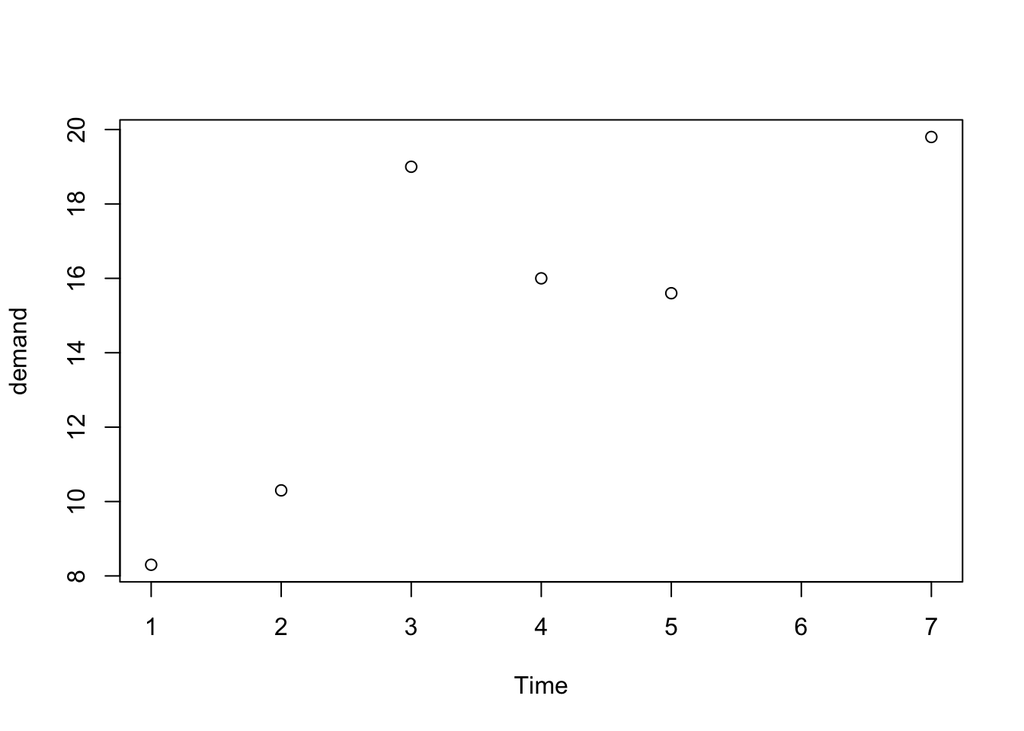

```r
?BOD

plot(BOD)
```

10. How many observations are in the BOD dataset?
- 6 observations
11. How many variables are in the dataset?
- 2 variables
12. What are the names of the two variables?
- time and demand
13. What are the units of Time and demand?
- The unit of time is days while the unit of demand is mg/L.
14. What type of graph is produced by plot(BOD)?
- The type of graph produced is a scatterplot.
15. Why is this type of graph appropriate for examining the relationship between the variables?
- A scatterplot is appropriate because it shows the relationship between two numerical variables. It makes it easier to see patterns or trends between Time and demand.
16. How can R, RStudio, R Markdown, Git, and GitHub support reproducible biological research?
- R and RStudio allow researchers to analyze and organize biological data using reproducible code instead of relying only on manual calculations. R Markdown can combine the code, results, graphs, and explanations in one document. This makes the research process easier to follow and repeat. Git tracks changes made to files, while GitHub stores and shares the project online, which allows researchers to keep a record of their work and collaborate with others. All of these tools make biological research more organized, transparent, and reproducible, since other researchers can review the methods and repeat the same analysis.

Reflection

- Today’s activity helped me become more familiar with R, RStudio, R Markdown, Git, and GitHub. At first, some of the tools and commands were unfamiliar, but following the activities made them easier to understand and use. I also learned the importance of keeping files organized and documenting my work properly. Overall, the activity gave me a better understanding of how these tools can be used for data analysis and reproducible research.

Conclusion

- In conclusion, Exercise 1 provided an introduction to the basic use of R and RStudio for biological data analysis. We practiced creating an RStudio project, writing and running R scripts, exploring the BOD dataset, and creating simple plots. We also learned how R Markdown can organize code, text, and results into one document. Lastly, we were introduced to Git and GitHub for organizing files and tracking changes in our work. These activities help us with the basic skills needed for organized and reproducible data analysis which is important for scientific research.